# Evaluating the Impact of $100 Gift Cards on Vaccination Rates in Minnesota

Richard Bamattre

Looking at vaccine rates nationally and evaluating the impact of Minnesota Department of Health offering $100 gift card incentives for the first half of August 2021.

Studies like [this assessment of the vaccine lottery in Ohio](https://jamanetwork.com/journals/jama/fullarticle/2781792) are models for this approach.

[This study](https://bmcmedresmethodol.biomedcentral.com/articles/10.1186/s12874-021-01235-8) uses the fable package and gets more into the math.

**Note: This is an experiment to try out a method that I’m not very familiar with. It should not be construed as a reputable or peer-reviewed evaluation of vaccine incentives**

```r
knitr::opts_chunk$set(warning = FALSE, message = FALSE)
# load
library(tidycensus)
#Sys.setenv(CENSUS_KEY = "[census api key here]")
census_api_key(Sys.getenv("CENSUS_KEY"))

# wrangle
library(tidyverse) # of course
library(janitor) # nice tables

# viz
library(ggthemes) # extra ggplot themes
library(gghighlight) # highlight key elements in ggplot

# model
library(tsibble) # time series tibbles/dataframes, required for fable
library(fable) # forecasting
library(feasts) # additional tools for forecasting
```

# Get data

## Data source

Originally used Johns Hopkins cleaned up data, but this only had cumulative doses. Switched to [Our World In Data](https://github.com/owid/covid-19-data/tree/master/public/data/vaccinations/), which downloads from the CDC for US Vaccinations.

This data is nice because vaccination rates per 100 or million are calculated.

```r
#vacc <- read_csv("https://github.com/govex/COVID-19/blob/master/data_tables/vaccine_data/us_data/time_series/people_vaccinated_us_timeline.csv?raw=true")

vacc <- read_csv("https://raw.githubusercontent.com/owid/covid-19-data/master/public/data/vaccinations/us_state_vaccinations.csv")

unique(vacc$location)
```

```
##  [1] "Alabama"                        "Alaska"
##  [3] "American Samoa"                 "Arizona"
##  [5] "Arkansas"                       "Bureau of Prisons"
##  [7] "California"                     "Colorado"
##  [9] "Connecticut"                    "Delaware"
## [11] "Dept of Defense"                "District of Columbia"
## [13] "Federated States of Micronesia" "Florida"
## [15] "Georgia"                        "Guam"
## [17] "Hawaii"                         "Idaho"
## [19] "Illinois"                       "Indian Health Svc"
## [21] "Indiana"                        "Iowa"
## [23] "Kansas"                         "Kentucky"
## [25] "Long Term Care"                 "Louisiana"
## [27] "Maine"                          "Marshall Islands"
## [29] "Maryland"                       "Massachusetts"
```

[output cut: 18 more lines]

## Total vaccinations nationally

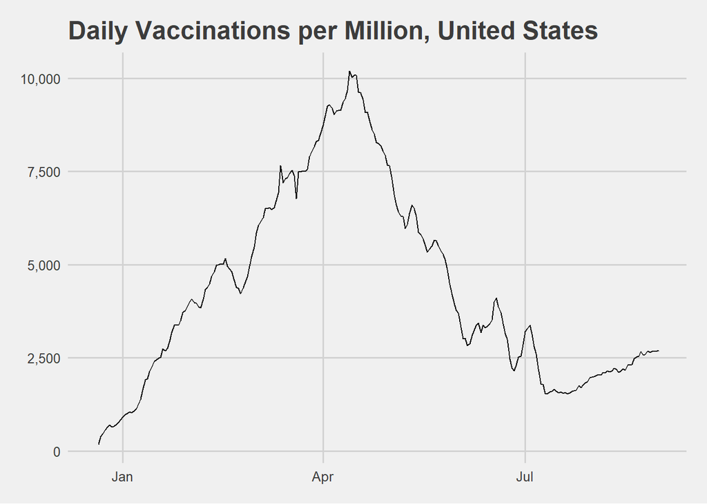

```r
vacc %>%
  filter(location == "United States") %>%
  ggplot(aes(x = date, y = daily_vaccinations_per_million)) +
    geom_line() +
    scale_y_continuous(labels = scales::comma) +
    labs(title = "Daily Vaccinations per Million, United States",
         y = "") +
    theme_fivethirtyeight()
```

### Looking at Minnesota’s rate

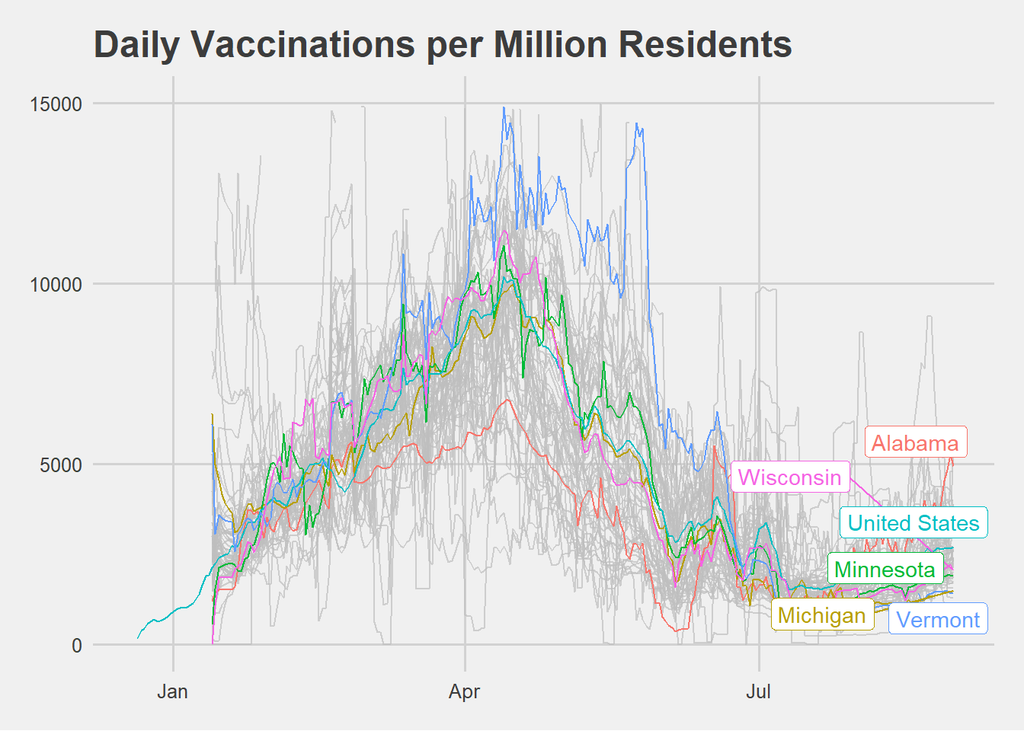

```r
vacc %>%
  ggplot(aes(x = date, y = daily_vaccinations_per_million, group = location,
             color = location)) +
    geom_line() +
    gghighlight(location %in% c("United States", "Minnesota", "Michigan",
                                "Wisconsin", "New York", "Alabama", "Vermont")) +
    labs(title = "Daily Vaccinations per Million Residents",
         y = "Vaccinations per million residents") +
    scale_y_continuous(labels = scales::comma) +
    ylim(0, 15000) +
    theme_fivethirtyeight()
```

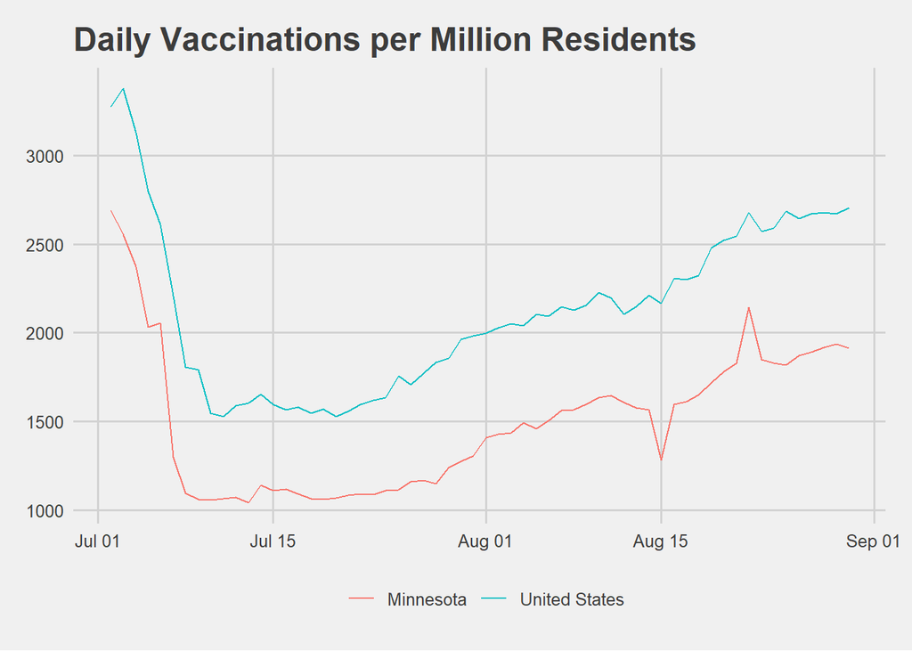

```r
vacc %>%
  filter(location %in% c("United States", "Minnesota"),
         date > '2021-07-01') %>%
  ggplot(aes(x = date, y = daily_vaccinations_per_million, group = location,
             color = location)) +
    geom_line() +
    theme_fivethirtyeight() +
    labs(title = "Daily Vaccinations per Million Residents",
         color = "")
```

## Research Question

**Research Question: Was incentives introduced in August associated with a relative increase in vaccination rates in MN (compared to the US)?**

Incentives for shots done 7/30 - 8/22 (was extended an extra week)

Trying out an Interrupted Time Series (ITS) Approach

Using this article as a guide.

## Create time series dataframe

Create a dataframe to resemble that in Table 2 in the article. This has the coefficient necessary to do a ITS analysis.

```r
its <- vacc %>%
  filter(location %in% c("United States", "Minnesota"),
         date > '2021-07-14',
         date <= '2021-08-22') %>%
  select(location, date, daily_vaccinations_per_million) %>%
  pivot_wider(names_from = location, values_from = daily_vaccinations_per_million) %>%
  arrange(date) %>%
  mutate(diff = Minnesota - `United States`,
         prog = if_else(date >= '2021-07-30' & date <= '2021-08-22', 1, 0),
         time = row_number(),
         time_after = cumsum(prog))

its_ts <- its %>%
  as_tsibble(key = NULL, index = date)
```

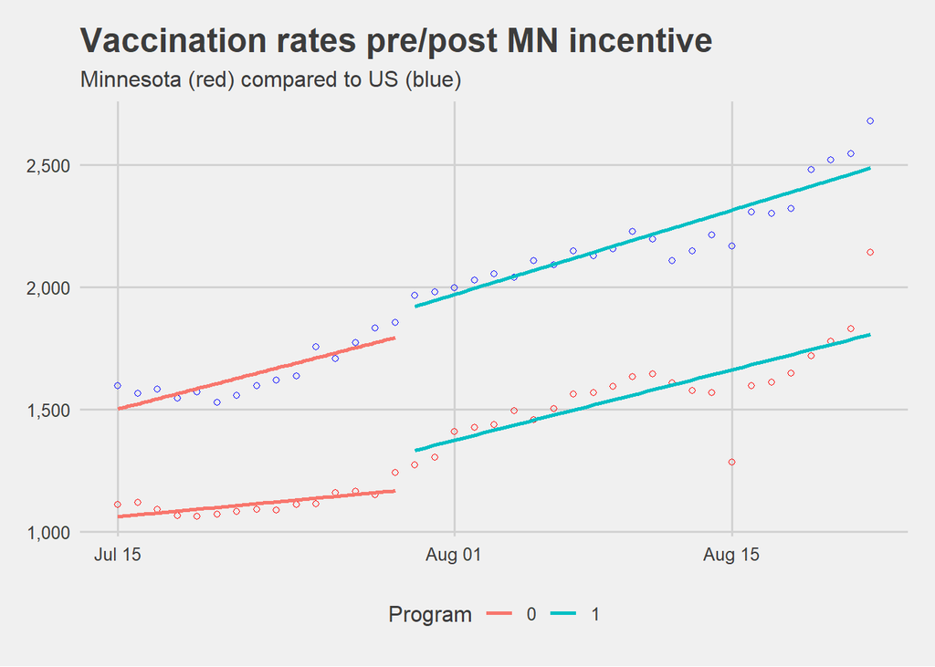

```r
its %>%
  ggplot(aes(x = date)) +
    geom_point(aes(y = Minnesota), color = "red", shape = 1) +
    geom_smooth(aes(y = Minnesota, group = prog, color = factor(prog)), method = "lm",
                se = FALSE) +
    geom_point(aes(y = `United States`), color = "blue", shape = 1) +
    geom_smooth(aes(y = `United States`, group = prog, color = factor(prog)), method = "lm",
                se = FALSE) +
    labs(title = "Vaccination rates pre/post MN incentive",
         subtitle = "Minnesota (red) compared to US (blue)", y = "At least one vaccine per 100,000 people",
         color = "Program") +
    scale_y_continuous(labels = scales::comma) +
    theme_fivethirtyeight()
```

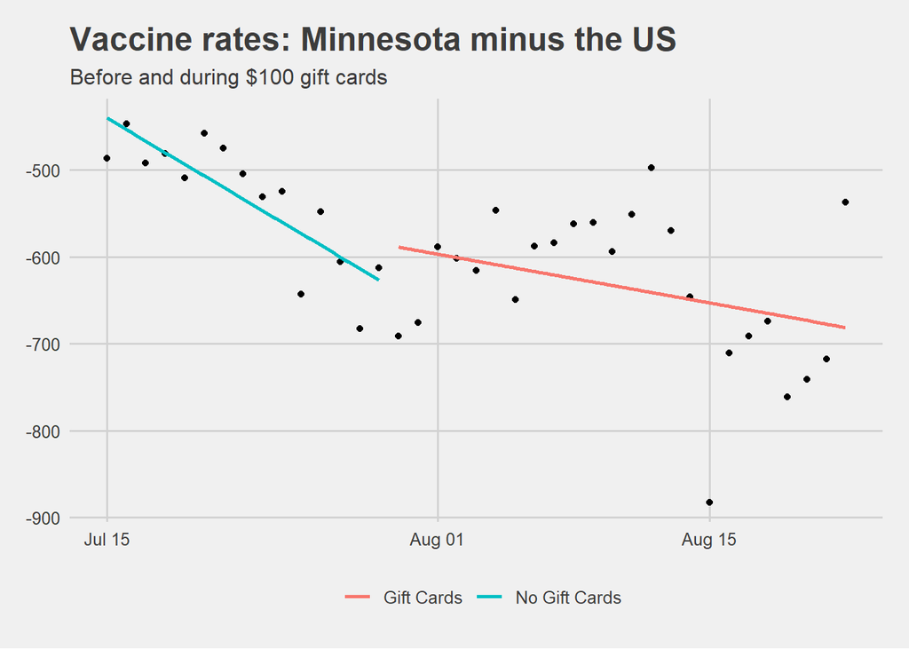

```r
its %>%
  mutate(Program = if_else(prog == 1, "Gift Cards", "No Gift Cards")) %>%
  ggplot(aes(x = date, y = diff)) +
    geom_point() +
    geom_smooth(aes(group = Program, color = factor(Program)), method = "lm",
                se = FALSE) +
    labs(title = "Vaccine rates: Minnesota minus the US",
         subtitle = "Before and during $100 gift cards", y = "Difference in vaccines per 100,000 people",
         color = "") +
    scale_y_continuous(labels = scales::comma) +
    theme_fivethirtyeight()
```

## LM Model

Fit a linear regression model, without considering autocorrelation or seasonality (that’s modeled by ARIMA).

The assumption of this is that errors are not correlated - but it’s a time series so they are.

```r
its_tb <- its_ts %>% as_tibble

lm <- lm(diff ~ time + prog + time_after, data = its_tb)

summary(lm)
```

```
##
## Call:
## lm(formula = diff ~ time + prog + time_after, data = its_tb)
##
## Residuals:
##      Min       1Q   Median       3Q      Max
## -229.898  -38.443    3.079   38.890  144.260
##
## Coefficients:
##             Estimate Std. Error t value Pr(>|t|)
## (Intercept) -427.019     39.177 -10.900 8.49e-13 ***
## time         -13.314      4.309  -3.090  0.00391 **
## prog          42.016     46.683   0.900  0.37425
## time_after     9.292      4.805   1.934  0.06126 .
## ---
## Signif. codes:  0 '***' 0.001 '**' 0.01 '*' 0.05 '.' 0.1 ' ' 1
##
## Residual standard error: 72.1 on 35 degrees of freedom
## Multiple R-squared:  0.473,  Adjusted R-squared:  0.4278
## F-statistic: 10.47 on 3 and 35 DF,  p-value: 4.628e-05
```

## ARIMA Model

Fit model using regression equation:

rate = 0 + time + program + time after program + e

```r
model <- its_ts %>%
  model(ARIMA(diff ~ time + prog + time_after))

report(model)
```

```
## Series: diff
## Model: LM w/ ARIMA(1,0,0)(0,0,1)[7] errors
##
## Coefficients:
##          ar1     sma1     time      prog  time_after  intercept
##       0.3349  -0.6460  -8.0493  -12.7671      5.0333  -465.6193
## s.e.  0.1571   0.1835   4.8041   47.9277      5.3523    42.4656
##
## sigma^2 estimated as 3096:  log likelihood=-210.76
## AIC=435.51   AICc=439.12   BIC=447.16
```

### Assess residuals

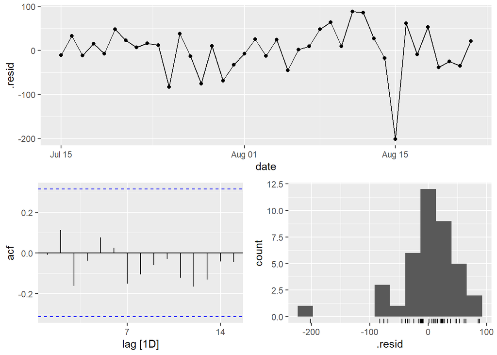

```r
model %>%
  gg_tsresiduals()
```

### Get full table of coefficients

```r
results <- model[[1]][[1]]$fit$par

results2 <- results %>%
  mutate(p.value = if_else(p.value < .001, "<0.001", as.character(round(p.value, 3))))

results2
```

| term | estimate | std.error | statistic | p.value |
| --- | --- | --- | --- | --- |
| ar1 | 0.3348602 | 0.1571177 | 2.1312702 | 0.039 |
| sma1 | -0.6460003 | 0.1834786 | -3.5208486 | 0.001 |
| time | -8.0492673 | 4.8040978 | -1.6755003 | 0.102 |
| prog | -12.7671231 | 47.9276897 | -0.2663830 | 0.791 |
| time_after | 5.0332527 | 5.3523477 | 0.9403822 | 0.353 |
| intercept | -465.6192538 | 42.4656000 | -10.9646221 | <0.001 |

Time controls for the trend, is not important but shows that rates were not trending overall to a stat sig degree

Time after is not significant, there was not a stat sig trend up during the program

Program here is not significant, so there was no evidence the program had an impact in vaccination rates compared to the US.

### Counterfactual plot

How to plot the counterfactual? i.e. where MN would have expected vaccine rates if following the trend of the US? This may not be very empirical, but it should provide an engaging plot to see how rates differed over time.

Let’s create a tidy tsibble, model both MN and USA, and compare the predictions versus the actual while the incentive was in place.

Should we use all available data to forecast, not just from July?

```r
its_all <- vacc %>%
  filter(location %in% c("United States", "Minnesota"),
         #date > '2021-07-14',
         date <= '2021-08-22') %>%
  select(location, date, daily_vaccinations_per_million) %>%
  pivot_wider(names_from = location, values_from = daily_vaccinations_per_million) %>%
  arrange(date) %>%
  mutate(diff = Minnesota - `United States`,
         prog = if_else(date >= '2021-07-30' & date <= '2021-08-22', 1, 0),
         time = row_number(),
         time_after = cumsum(prog))

its_all_ts <- its_all %>%
  pivot_longer(Minnesota:`United States`, names_to = "region", values_to = "vacc_rate") %>%
  select(date, prog, region, vacc_rate) %>%
  as_tsibble(key = region, index = date)

train_model = its_all_ts %>%
  filter(prog == 0) %>%
  model(ARIMA(vacc_rate))

train_model
```

| region | ARIMA(vacc_rate) |
| --- | --- |
| Minnesota |  |
| United States |  |

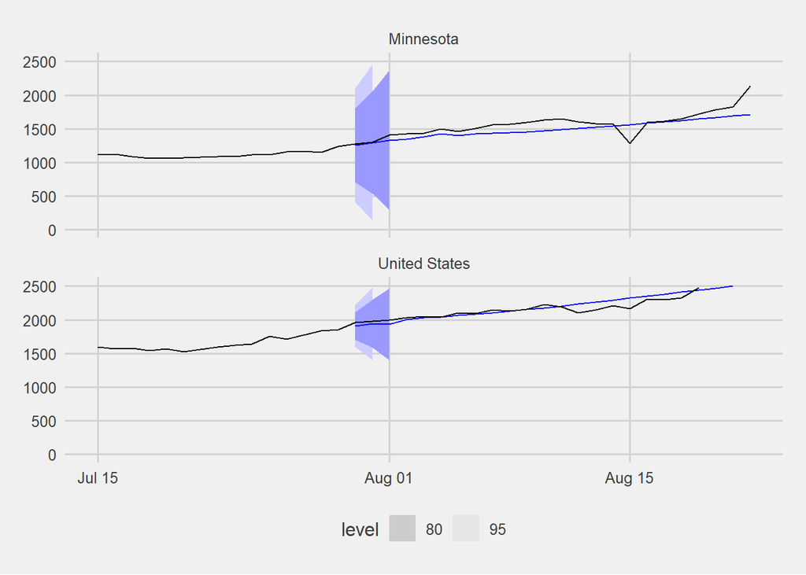

```r
its_fc <- train_model %>%
  forecast(h = 24)

its_fc %>%
  autoplot(
    its_all_ts %>% filter_index("2021-07-15" ~ .)
  ) +
    theme_fivethirtyeight() +
    ylim(0, 2500)
```

[figure not shown]

```r
# extract points, turn fable -> tibble

mn_fc <- its_fc %>%
  filter(region == "Minnesota") %>%
  as_tibble() %>%
  full_join(its %>% select(date, Minnesota, `United States`, prog), by = "date") %>%
  select(date, `Forecasted Minnesota` = .mean, `Actual Minnesota` = Minnesota, `United States`, prog) %>%
  pivot_longer(`Forecasted Minnesota`:`United States`)

mn_fc %>%
  ggplot(aes(x = date, y = value, group = name, color = name)) +
    geom_point(shape = 1) +
    geom_smooth(data = mn_fc %>% filter(prog == 1), method = "lm", se = FALSE) +
    geom_smooth(data = mn_fc %>% filter(prog == 0), method = "lm", se = FALSE) +
    geom_vline(xintercept = as.Date("2021-07-30")) +
    theme_fivethirtyeight() +
    labs(title = "$100 Incentive and Impact on Vaccine Rates",
         subtitle = "Forecasted rates based on ARIMA model", color = "",
         caption = "@rbamattre | Source: Johns Hopkins")
```

## ARIMA - No counterfactual

Based on Schaffer et al., we could do an Interrupted Time Series just with MN (where the counterfactual is the predicted rates).

```r
model2 <- its_ts %>%
  model(ARIMA(Minnesota ~ time + prog + time_after))

report(model2)
```

```
## Series: Minnesota
## Model: LM w/ ARIMA(1,0,0)(1,0,1)[7] errors
##
## Coefficients:
##          ar1     sar1     sma1     time     prog  time_after  intercept
##       0.3858  -0.1844  -0.7454  15.6476  37.0056      6.7336  1006.2533
## s.e.  0.1695   0.2973   0.4716   5.8712  58.2137      6.8590    53.7047
##
## sigma^2 estimated as 4275:  log likelihood=-218.36
## AIC=452.71   AICc=457.51   BIC=466.02
```

### Assess residuals

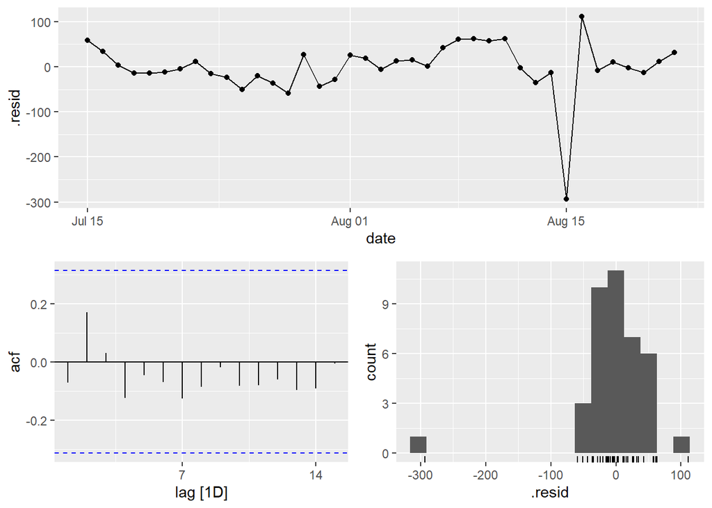

```r
model2 %>%
  gg_tsresiduals()
```

### See results

```r
results2 <- model2[[1]][[1]]$fit$par

results3 <- results2 %>%
  mutate(p.value = if_else(p.value < .001, "<0.001", as.character(round(p.value, 3))))

results3
```

| term | estimate | std.error | statistic | p.value |
| --- | --- | --- | --- | --- |
| ar1 | 0.3858051 | 0.1694618 | 2.2766489 | 0.028 |
| sar1 | -0.1843694 | 0.2972559 | -0.6202382 | 0.539 |
| sma1 | -0.7453836 | 0.4716161 | -1.5804878 | 0.122 |
| time | 15.6475831 | 5.8712049 | 2.6651400 | 0.011 |
| prog | 37.0056008 | 58.2137342 | 0.6356851 | 0.529 |
| time_after | 6.7336418 | 6.8589924 | 0.9817246 | 0.332 |
| intercept | 1006.2533001 | 53.7047243 | 18.7367743 | <0.001 |

Here there is still no significant impact related with the program.

### Plot

By itself this plot looks like there was an impact, but there was not a significant impact based on modeling, and also there was an increase in the United States in vaccinations since late July, perhaps due to news around the Delta variant.

[figure not shown]

```r
mn_fc_alone <- mn_fc %>%
  filter(name != "United States")

mn_fc_alone %>%
  ggplot(aes(x = date, y = value, group = name, color = name)) +
    geom_point(shape = 1) +
    geom_smooth(data = mn_fc_alone %>% filter(prog == 1), method = "lm", se = FALSE) +
    geom_smooth(data = mn_fc_alone %>% filter(prog == 0), method = "lm", se = FALSE) +
    geom_vline(xintercept = as.Date("2021-07-30")) +
    theme_fivethirtyeight() +
    labs(title = "$100 Incentive and Impact on Vaccine Rates",
         subtitle = "Small and non-statistically significant increase in vaccines", color = "",
         y = "Daily vaccinations per million",
         caption = "@rbamattre | Source: Johns Hopkins") +
    theme(axis.title.y = element_text())
```

## Confounding variables

Comparing MN to the US would be problematic if the US had certain regions with different trends that made a national trend that was not very comparable. For example, the East Coast has lower trends because more people are vaccinated, and there is increasing vaccines in the South, since less people are vaccination, and the result of these two trends is a generally stable trend. In other words, what is a good comparison to Minnesota?

Consider comparing Minnesota with other states with similar vaccination rates (percent of population vaccinated to date).

### Vaccination rates by region

Compare regions to see if there are different rates. Haven’t done this yet.

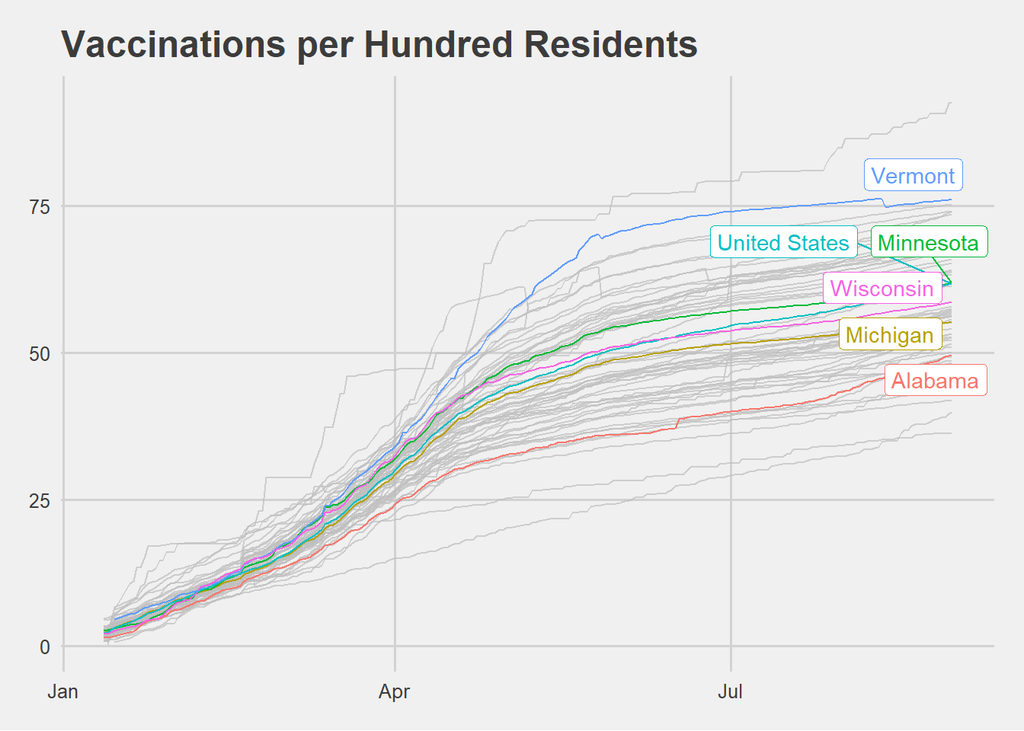

```r
vacc %>%
  filter(!is.na(people_fully_vaccinated_per_hundred)) %>%
  ggplot(aes(x = date, y = people_vaccinated_per_hundred, group = location,
             color = location)) +
    geom_line() +
    gghighlight(location %in% c("United States", "Minnesota", "Michigan",
                                "Wisconsin", "New York", "Alabama", "Vermont")) +
    labs(title = "Vaccinations per Hundred Residents",
         y = "Vaccinations per Hundred Residents") +
    scale_y_continuous(labels = scales::comma) +
    theme_fivethirtyeight()
```

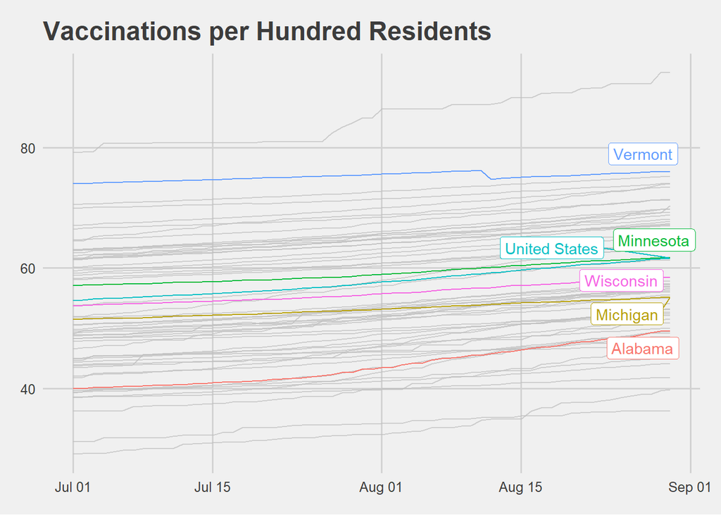

```r
vacc %>%
  filter(!is.na(people_fully_vaccinated_per_hundred),
         date >= '2021-07-01') %>%
  ggplot(aes(x = date, y = people_vaccinated_per_hundred, group = location,
             color = location)) +
    geom_line() +
    gghighlight(location %in% c("United States", "Minnesota", "Michigan",
                                "Wisconsin", "New York", "Alabama", "Vermont")) +
    labs(title = "Vaccinations per Hundred Residents",
         y = "Vaccinations per Hundred Residents") +
    scale_y_continuous(labels = scales::comma) +
    theme_fivethirtyeight()
```

[output not shown]